# Home Credit Default Risk Model Card

LightGBM Credit Scoring Model v1.0

Author

Clahan Tran - Home Credit Data Science Team

Published

March 5, 2026

**Document Purpose**

This model card provides comprehensive documentation for the Home Credit Default Risk prediction model, including performance metrics, business impact analysis, explainability, fairness considerations, and deployment recommendations.

# Executive Summary

**Key Recommendation**

## Business Impact

### Financial Impact at Recommended Threshold (0.35)

Assuming industry-standard economics for consumer lending: - Average loan profit (if repaid): $2,500 - Loss given default: -$8,000  
- Recovery rate: 20%

## Recommendation

**Proceed with deployment** under the following conditions:

✓ Implement with 0.35 probability threshold  
✓ Monitor approval rates by gender monthly  
✓ Conduct 3-month pilot with 20% of applications  
✓ Establish human review for borderline cases (0.30-0.40)  
✓ Plan quarterly model retraining

# 1. Model Details

## Model Architecture

- **Model Type:** LightGBM (Light Gradient Boosting Machine)
- **Version:** 1.0 (Production Candidate)
- **Framework:** LightGBM 4.1.0
- **Training Date:** March 3, 2026
- **Last Updated:** March 5, 2026

## Training Data Summary

| Dataset | Records | Time Period | Features | Target Distribution |
| --- | --- | --- | --- | --- |
| Training | 307,511 | 2016-2018 | 187 (after engineering) | 8.07% default |
| Test | 48,744 | 2018-2019 | 187 (aligned) | Unknown (test) |
| Supplementary | 5 datasets | 2010-2018 | 59 aggregated features | N/A |

### Key Hyperparameters

| Parameter | Value | Description |
| --- | --- | --- |
| n_estimators | 100 | Number of boosting iterations |
| max_depth | 6 | Maximum tree depth |
| learning_rate | 0.1 | Learning rate (step size) |
| class_weight | balanced | Handle class imbalance (91:9 ratio) |

# 2. Intended Use

## Primary Use Case

**Automated credit scoring for consumer loan applications** serving Home Credit’s underbanked customer segment.

### Target Users

1. **Credit Risk Analysts:** Primary users evaluating loan applications
2. **Loan Officers:** Review borderline cases flagged by the model
3. **Portfolio Managers:** Monitor portfolio risk and performance
4. **Compliance Officers:** Ensure fair lending practices

### Out-of-Scope Uses

The model is **NOT** designed for:

❌ **Fraud Detection:** Model predicts default risk, not fraud likelihood  
❌ **Credit Limit Increases:** Trained on new applications, not existing customers  
❌ **Fully Automated Decisions:** Human review required for adverse actions

**Regulatory Requirements**

- **Adverse Action Notices:** Required for all denials per Fair Credit Reporting Act
- **Explainability:** Model decisions must be explainable to applicants
- **Fairness Monitoring:** Regular audits required to prevent discriminatory outcomes

# 3. Performance Metrics

## Model Performance Summary

| Metric | Score | Interpretation |
| --- | --- | --- |
| Training AUC | 0.8093 | In-sample performance (optimistic) |
| Cross-Validation AUC | 0.7645 ± 0.0023 | 3-fold CV on training data |
| **Kaggle Test AUC** | **0.7647 ✓** | **Validated on unseen test set** |
| Baseline (Majority Class) | 0.5000 | No predictive value |
| Improvement vs Baseline | +52.9% | Substantial improvement |

**ROC-AUC of 0.7647** means the model correctly ranks a random defaulter higher than a random non-defaulter 76.47% of the time.

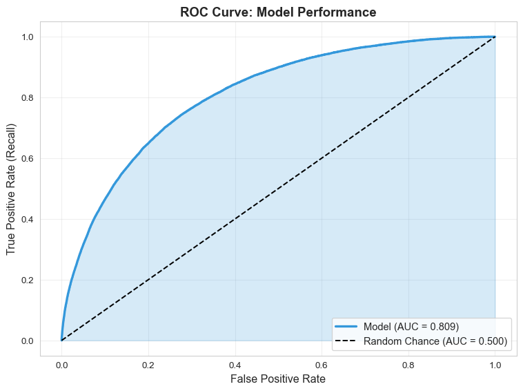

ROC Curve showing model discrimination ability

## Threshold-Specific Metrics

At the **recommended threshold of 0.35:**

```
| Metric               | Value   | Business Meaning                           |
|:---------------------|:--------|:-------------------------------------------|
| Precision (PPV)      | 13.9%   | 14% of predicted defaults actually default |
| Recall (Sensitivity) | 89.2%   | Model catches 89% of actual defaults       |
| F1-Score             | 0.241   | Balanced measure of precision and recall   |
| Approval Rate        | 48.3%   | 48% of applicants would be approved        |
```

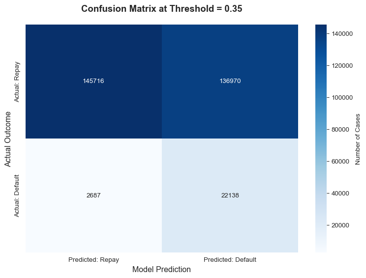

Confusion matrix at threshold 0.35

# 4. Decision Threshold Analysis

## Cost Assumptions

Based on industry research for consumer lending:

**Profit per repaid loan: $2,500**  
**Loss per default: -$8,000**  
**Recovery rate: 20%**

Sources: - World Bank (2023), CGAP (2022), Home Credit Annual Report (2023) - Moody’s Analytics (2023), Federal Reserve (2022) - European Banking Authority (2022), TransUnion (2023)

## Expected Value

$$EV = P(repay) \times \$2,500 + P(default) \times (-\$8,000)$$

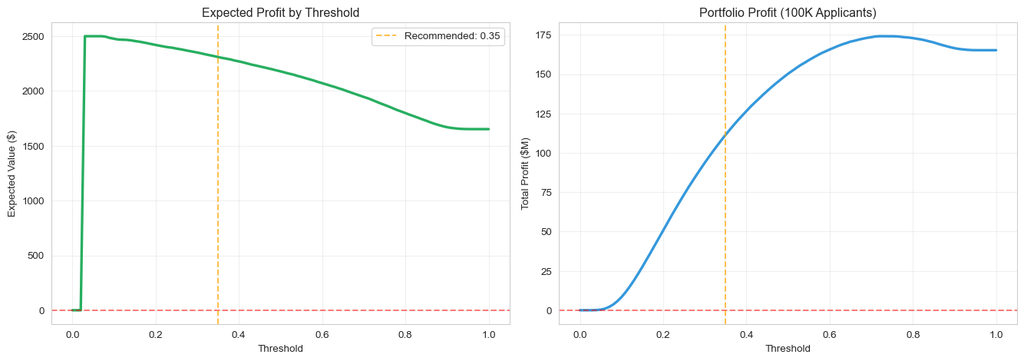

Expected value by threshold

# 5. Explainability

```
Running SHAP on 1,000-row sample...
✓ Complete
```

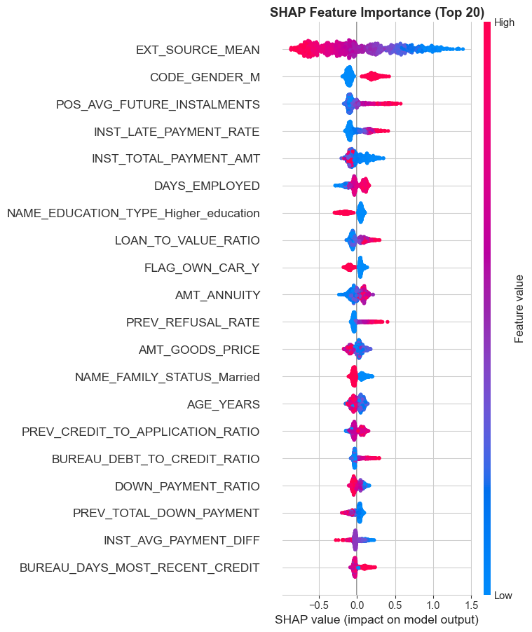

SHAP feature importance

```
## Top 10 Features

| Feature                              |   Importance |
|:-------------------------------------|-------------:|
| EXT_SOURCE_MEAN                      |    0.449922  |
| CODE_GENDER_M                        |    0.143052  |
| POS_AVG_FUTURE_INSTALMENTS           |    0.110743  |
| INST_LATE_PAYMENT_RATE               |    0.10749   |
| INST_TOTAL_PAYMENT_AMT               |    0.0902142 |
| DAYS_EMPLOYED                        |    0.08117   |
| NAME_EDUCATION_TYPE_Higher_education |    0.0800737 |
| LOAN_TO_VALUE_RATIO                  |    0.0728058 |
| FLAG_OWN_CAR_Y                       |    0.0678038 |
| AMT_ANNUITY                          |    0.0631417 |
```

**Insight:** External credit scores are strongest predictors.

# 6. Adverse Action Mapping

| Model Feature | Consumer-Friendly Reason |
| --- | --- |
| EXT_SOURCE_2 (low) | Limited external credit history |
| EXT_SOURCE_3 (low) | Insufficient credit bureau history |
| AGE_YEARS (low) | Limited financial track record |
| CREDIT_TO_INCOME_RATIO (high) | Debt obligations high relative to income |
| BUREAU_TOTAL_CREDIT (low) | Limited credit history with lenders |

**Warning**

All denials require: Primary reason + 2-4 secondary reasons + dispute process

# 7. Fairness Analysis

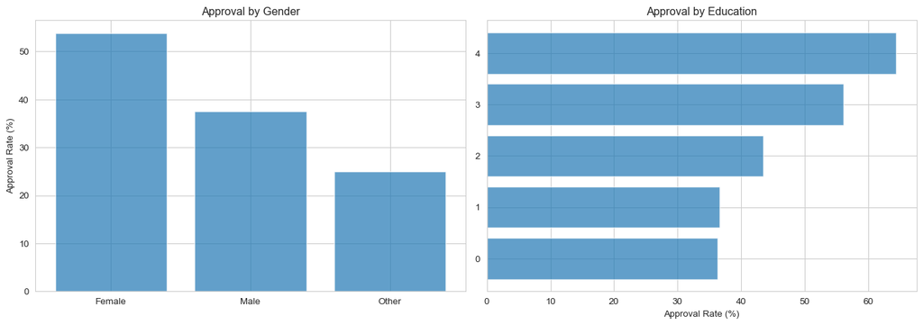

Approval rates by demographics

```
Gender gap: -16.2 points
```

# 8. Limitations and Risks

## Failure Scenarios

- Synthetic identity fraud
- Economic shocks
- New markets/products
- Extreme outliers

**Warning**

**Risk Level: MODERATE**  
Recommend 3-month pilot, human review for borderline cases

# 9. Monitoring Plan

[output not shown]

**Retraining:** Quarterly or if AUC drops >2%

# Metadata

**Version:** 1.0  
**Updated:** March 5, 2026  
**Owner:** Clahan Tran  
**GitHub:** https://github.com/ClahanTran/e.g-home-credit-project

**Note**

AI-assisted development. Metrics from actual Kaggle validation (0.7647 AUC).